# Lab_10

Data Me Pls: Chris, James, Amanda, Anna

March 17, 2019

# Fourm Data

## Timeliness of a Post

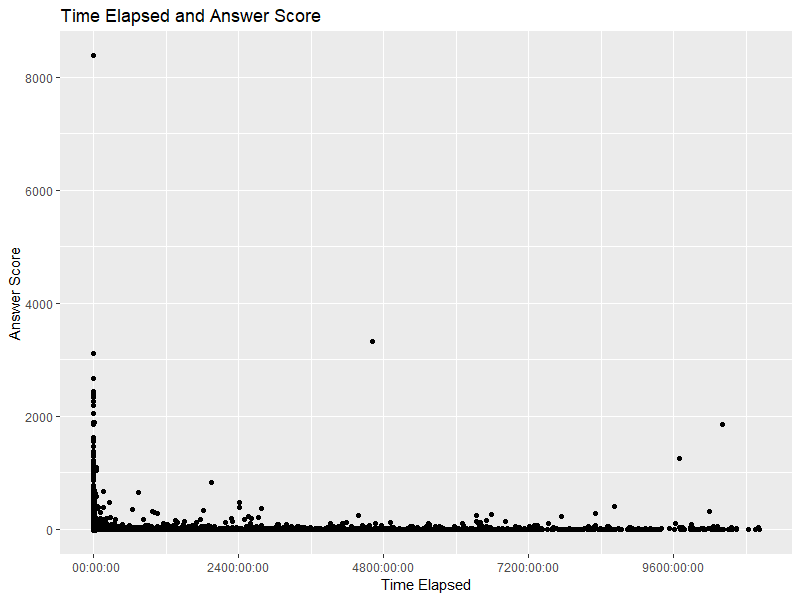

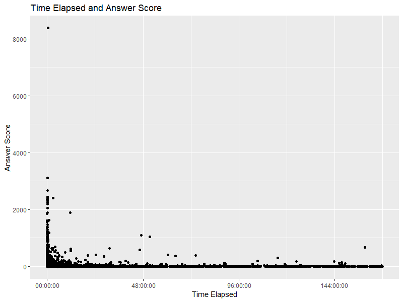

```r
library(hms)

time <- QnA%>%
  select(Qid, QDate, ADate, AScore)

etime <- time%>%
  mutate(Etime= ADate-QDate)

etime1 <- etime%>%
  filter(Etime >= 0)%>%
  mutate(Etimeh= as.hms(Etime))

etime2 <- etime1%>%
  filter(Etime<= 604800)

ggplot(etime1)+
  geom_point(mapping= aes(x=Etimeh, y=AScore))+
  labs(x= "Time Elapsed", y= "Answer Score",
       title= "Time Elapsed and Answer Score")

ggplot(etime2)+
  geom_point(mapping= aes(x=Etimeh, y=AScore))+
  labs(x= "Time Elapsed", y= "Answer Score",
       title= "Time Elapsed and Answer Score")
```

## Other Important Features

If someone refers to a link in their answer, they are more likely to get a better score/upvote. If someone uses a question mark in their question, it would tend to get a better score. There is a small correlation between using first person in answers and getting worse scores, but not a huge one. Some answers score higher than the question, but it is unlikely and for large differences, both the question and answers have to be scored highly.

### Chris

**Question:** Do answers that contain a link in them get more upvotes?

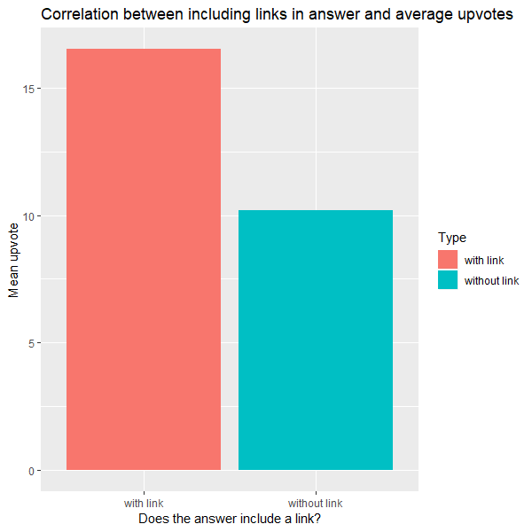

```r
links <- answersj %>%
  select("Score", "Body")

containslink <- links %>%
  filter(str_detect(Body, "http")) %>%
  select(Score)

score_wlink <- containslink %>%
  transform(Score = as.numeric(Score)) %>%
  summarise(mean_score = mean(Score))

#average score which contains links and then average scores of ones that don't contain links and compare.

doesntcontainlink <- links %>%
  filter(!str_detect(Body,"http")) %>%
  select(Score)

score_wolink <- doesntcontainlink %>%
  transform(Score = as.numeric(Score)) %>%
  summarise(mean_score = mean(Score))

scorestotal = full_join(score_wlink, score_wolink) %>%
  mutate(Type = c("with link", "without link"))

ggplot(scorestotal) +
  geom_col(aes(x = Type, y = mean_score, fill = Type)) + labs(x = "Does the answer include a link?", y = "Mean upvote", title = "Correlation between including links in answer and average upvotes")
```

From the data, we can see that, on average, answers that provide a link to support their response receive a better score (16.53 upvotes on average) than those that do not (10.21 upvotes on average). To be exact answers that include links are 6.32 upvotes higher on average.

I chose to analyze this feature because, in my experience, the answers that link to other articles are more intricate. Those answers tend to be very detailed, and the links are to either references, or to another article that can answer a specific aspect of the question in more detail. I was curious if the people who linked other sources would get higher upvotes because of this.

Again, I think the reason that people who included links in their responses had much higher average upvotes is due to them referring to other sources when they know they are unable to adequately answer a specific portion of the question

### James

**Questions:** Does the ratio of word count for the title and body affect the score? The feature I analyzed was this ratio. I don’t believe there will be a strong correlation with this feature and scores, but I do believe that it’s something to observe. Questions that have titles that are longer than their bodies have a ratio that is greater than one, and questions that have titles shorter than their bodies have a ratio less than one. My expectation is higher scored questions have a ratio less than 1.

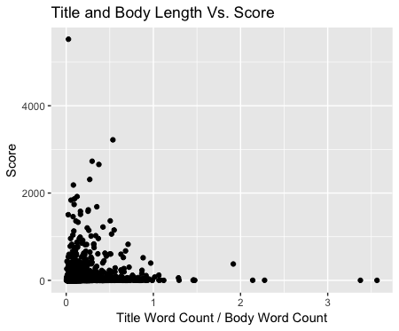

One can clearly see that there is some “correlation.” As this ratio approaches 0, the range of scores increases. However, this could be due to short titles and descriptive body paragraphs.

**Answers:** Do answers that have question marks in them get more upvotes? The feature I analyzed was a categorical variable, that outputs TRUE if there is a “?” and FALSE if not. I thought this was a reasonable feature because one would assume that the best answers don’t actually respond with questions.

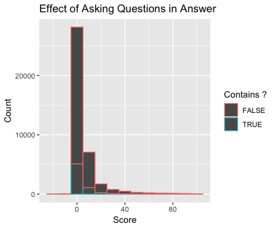

### Amanda

**Questions:** Do questions that include a question mark generally receive more upvotes than questions that do not include a question mark?

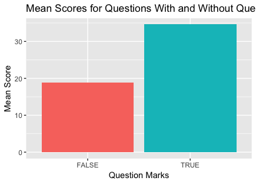

```r
questions1 <- questions %>% mutate(questionMarks = str_detect(Title, "\\?"))
#View(questions1)
questions2 <- questions1 %>%
  select(Score, questionMarks)%>%
  group_by(questionMarks)%>%
  summarise(mean= mean(Score))
#View(questions2)
ggplot(data=questions2, aes(x=questionMarks, y=mean, fill=questionMarks)) + geom_col() +labs(title="Mean Scores for Questions With and Without Question Marks", x="Question Marks", y="Mean Score") + theme(legend.position="none")
```

This graph looks at how scores for questions may vary based on whether or not they used a question mark in the question. “TRUE” indicates that the question did have a question mark in it while “FALSE” indicates that the question did not have a question mark in it.

I used geom_col() so I could plot the means for each category directly next to each other. First, I added the feature of a boolean variable that states whether or not the question has a question mark. Then I summarised the data to get the mean score for all the questions with and without question marks, and also added color and labels to the graph to make it more aesthetically pleasing.

From this graph, it is clear that questions with question marks received on average, higher scores than questions without question marks.

**Answers:** Do answers that use “I statements get more upvotes than ones that don’t?”

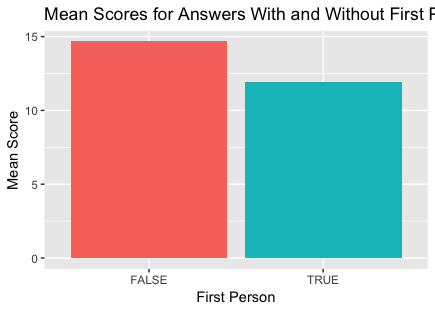

```r
answers1 <- answers %>% mutate(firstPerson = str_detect(Body, "I"))
#View(questions1)
answers2 <- answers1 %>%
  select(Score, firstPerson)%>%
  group_by(firstPerson)%>%
  summarise(mean1= mean(Score))
#View(questions2)
ggplot(data=answers2, aes(x=firstPerson, y=mean1, fill=firstPerson)) + geom_col() +labs(title="Mean Scores for Answers With and Without First Person", x="First Person", y="Mean Score") + theme(legend.position="none")
```

This graph looks at how scores for answers change based on whether or not the answer used first person or not. I wanted to look at this because I thought it could be interesting to see if the type of point-of-view that a person used would affect how people reacted to their answers. Do people feel a stronger connection to answers that use “I” or a weaker one?

To make this graph, I created a new feature that is a boolean variable that says “TRUE” if the answer uses first person and “FALSE” if the answer does not have it. I then summarised the data to extract the mean score for all questions with and without first person, adding colors and labels to make it more aesthetically pleasing.

From this graph, it is clear that answers that don’t use “I” statements have slightly higher answers. However, the difference is not that big, especially compared to the huge difference between scores in questions that did or didn’t use question marks. I would be interested to see if this difference is statistically significant or not.

### Anna

**Question:** Why are answers sometimes scored higher than questions? I found this interesting because in most cases, you would expect the opposite (questions scored higher than answers) or an equal amount, as people score both questions and answers on relevancy to their life.

I first used the full join function to join the entire data set together by Id and Parent Id. I then created a category that reported the difference in answer score and question score. After that, I filtered the data so that the tibble would only show questions with answers scored higher than the original post. To plot the relation, I used a geom_point function to make the plot. The plot cuts off some data, but those were clearly outliers.

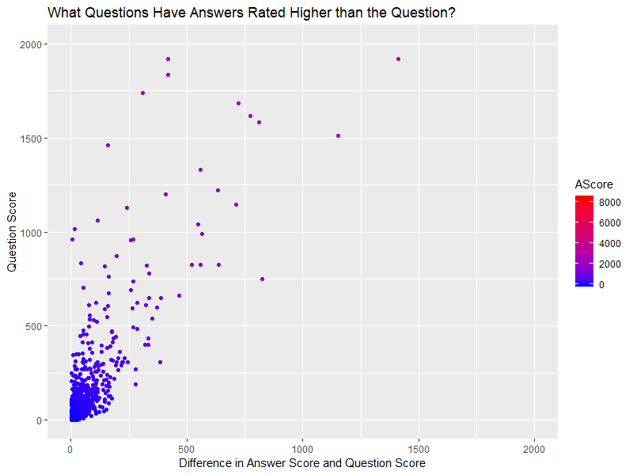

```r
#Reading the Files
answers <- read_csv("Answers_trunc.csv", col_names = TRUE)%>%
  select (Id, OwnerUserId, CreationDate, ParentId, Score, Body)
View(answers)

questions <- read_csv("Questions_trunc.csv", col_name= TRUE)%>%
  select(Id, OwnerUserId, CreationDate, Score, Title, Body)
View(questions)

#Join Function
answersj <- answers%>%
  rename(AnswerId= Id, Id= ParentId)

QnA <- full_join(questions, answersj, by= "Id")%>%
  rename(QDate= CreationDate.x,
         QScore= Score.x,
         QTitle= Title,
         QBody= Body.x,
         ADate= CreationDate.y,
         AScore= Score.y,
         ABody= Body.y,
         AUserId= OwnerUserId.y,
         QUserId= OwnerUserId.x,
         Aid= AnswerId,
         Qid= Id
         )

QnA <- QnA%>%
  select(Qid, QTitle, QDate, QScore, QUserId, QBody,
         Aid, ADate, AScore, AUserId, ABody)

#Creating the Difference Category
updoot <- QnA%>%
  mutate(Diff= AScore-QScore)%>%
  na.omit

updoot1 <- updoot%>%
  filter(Diff > 0)

#ggplot
ggplot (updoot1)+
  geom_point(mapping=aes(x=Diff, y=QScore, color=AScore))+
  labs(x= "Difference in Answer Score and Question Score", y= "Question Score", title= "What Questions Have Answers Rated Higher than the Question?")+
  scale_x_continuous(limits= c(0,2000))+
  scale_y_continuous(limits= c(0,2000))+
  scale_fill_manual(name= "Answer Score")+
  scale_color_gradient(low="blue", high="red")
```

From the graph, you can see that there is a positive relationship between question score and the difference, meaning that the question has to be generally highly scored for an answer to have an even higher score. Similarly, most of the points where this happens only have a difference below 500 points.

This factor would be particularly useful if one wanted to research more into these cases as the overall probability that an answer would score higher than its question is around 3%.

### Summary:

**James:** I used dplyr and string functions for my features. I used geom_point and geom_histogram for my plots.

**Amanda:** See above section

**Anna:** I used a full join and a geom point to represent this new feature.